# Gabarito - Atividade 9

```python
import numpy as np
import pandas as pd
from sklearn import datasets
from sklearn.model_selection import train_test_split
import matplotlib.pyplot as plt
import seaborn as sns
import time
from sklearn.metrics import precision_recall_fscore_support
from sklearn.metrics import classification_report
import warnings
warnings.filterwarnings("ignore")
```

```python
weather=pd.read_csv("weatherHistory.csv", index_col=False, squeeze=True)
```

```python
weather['Precip Type']=weather['Precip Type'].fillna("other")
```

## 1. Utilize técnicas de aprendizado de máquina supervisionado para criar modelos para prever o tipo de precipitação (Precip Type) de acordo com outras variáveis. Teste pelo menos três algoritmos e responda:

## a) Qual a acurácia, precisão e revocação para cada rótulo (tipo de precipitação) para cada algoritmo testado? Existe algum algoritmo com resultados melhores?

```python
from sklearn.neighbors import KNeighborsClassifier
from sklearn.naive_bayes import BernoulliNB
from sklearn import tree

def classifier(X_train,X_test,Y_train,Y_test):
    #Aplicando KNN
    print(" KNN ")
    ini = time.time() #Inicio do calculo do tempo

    knn=KNeighborsClassifier()
    knn.fit(X_train,Y_train)

    end = time.time()
    knn_time = end - ini # Fim do calculo do tempo

    print(classification_report(Y_test,knn.predict(X_test)))
    print()

    #Aplicando Naive Bayes
    print("Naive Bayes")
    ini = time.time() #Inicio do calculo do tempo

    nb=BernoulliNB()
    nb.fit(X_train,Y_train)

    end = time.time()
    nb_time = end - ini # Fim do calculo do tempo

    print(classification_report(Y_test,nb.predict(X_test)))
    print()

    #Aplicando Arvore de Decisao
    print("Árvore de Decisão")
    ini = time.time() #Inicio do calculo do tempo

    dtc=tree.DecisionTreeClassifier()
    dtc.fit(X_train,Y_train)

    end = time.time()
    dtc_time = end - ini # Fim do calculo do tempo

    print(classification_report(Y_test,dtc.predict(X_test)))
```

```python
X_train,X_test,Y_train,Y_test=train_test_split(weather[['Temperature (C)',
       'Apparent Temperature (C)', 'Humidity', 'Wind Speed (km/h)',
       'Wind Bearing (degrees)', 'Visibility (km)', 'Loud Cover',
       'Pressure (millibars)']],weather['Precip Type'],test_size=0.2, random_state=0)

classifier(X_train,X_test,Y_train,Y_test)
```

```
 KNN
              precision    recall  f1-score   support

       other       0.69      0.24      0.36       111
        rain       0.98      0.99      0.99     17082
        snow       0.92      0.91      0.92      2098

    accuracy                           0.98     19291
   macro avg       0.87      0.71      0.75     19291
weighted avg       0.98      0.98      0.98     19291


Naive Bayes
              precision    recall  f1-score   support

       other       0.00      0.00      0.00       111
        rain       0.99      1.00      1.00     17082
        snow       1.00      1.00      1.00      2098

    accuracy                           0.99     19291
   macro avg       0.66      0.67      0.67     19291
weighted avg       0.99      0.99      0.99     19291


Árvore de Decisão
              precision    recall  f1-score   support

       other       0.48      0.42      0.45       111
        rain       1.00      1.00      1.00     17082
        snow       1.00      1.00      1.00      2098

    accuracy                           0.99     19291
   macro avg       0.83      0.81      0.82     19291
weighted avg       0.99      0.99      0.99     19291
```

A Árvore de Decisão apresentou melhores resultados se comparado com os outros algoritmos. Isso porque, apesar de possuir o mesmo valor de acurácia que o algoritmo Naive Bayes, a Árvore de Decisão apresentou melhores resultados em termos de precisão e revocação relativas às classes.

## b) É possível melhorar o algoritmo se forem selecionados alguns atributos em particular, ao invés de utilizar todos?

Verificando a correlação entre os outros atributos e o tipo de precipitação.

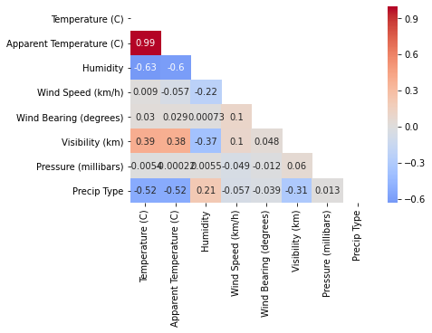

```python
cols = ['Temperature (C)',
       'Apparent Temperature (C)', 'Humidity', 'Wind Speed (km/h)',
       'Wind Bearing (degrees)', 'Visibility (km)',
       'Pressure (millibars)','Precip Type']
#Substituindo os valores de Precip Type para valores numéricos e calculando a correlação
Var_Corr = weather.replace(["rain","snow","other"],[1,2,3])[cols].corr()
matrix = np.triu(weather.replace(["rain","snow","other"],[1,2,3])[cols].corr())
sns.heatmap(Var_Corr, xticklabels=Var_Corr.columns, yticklabels=Var_Corr.columns,\
            annot=True,center= 0, cmap= 'coolwarm',mask=matrix)
```

Como 'Temperature (C)', 'Humidity' e 'Visibility (km)' possuem as maiores correlações (positivas e negativas), eles foram escolhidos como atributos para entrada dos modelos. No caso, o atributo 'Apparent Temperature (C)' também possui alta correlação, mas como é fortemente correlacionado com "Temperature (C)", foi eliminado.

```python
X_test = X_test[['Temperature (C)', 'Humidity', 'Visibility (km)']]
X_train = X_train[['Temperature (C)', 'Humidity', 'Visibility (km)']]
```

```python
classifier(X_train,X_test,Y_train,Y_test)
```

```
 KNN
              precision    recall  f1-score   support

       other       0.65      0.14      0.22       111
        rain       0.99      1.00      1.00     17082
        snow       0.99      1.00      0.99      2098

    accuracy                           0.99     19291
   macro avg       0.88      0.71      0.74     19291
weighted avg       0.99      0.99      0.99     19291


Naive Bayes
              precision    recall  f1-score   support

       other       0.00      0.00      0.00       111
        rain       0.99      1.00      1.00     17082
        snow       1.00      1.00      1.00      2098

    accuracy                           0.99     19291
   macro avg       0.66      0.67      0.67     19291
weighted avg       0.99      0.99      0.99     19291


Árvore de Decisão
              precision    recall  f1-score   support

       other       0.44      0.36      0.40       111
        rain       1.00      1.00      1.00     17082
        snow       1.00      1.00      1.00      2098

    accuracy                           0.99     19291
   macro avg       0.81      0.79      0.80     19291
weighted avg       0.99      0.99      0.99     19291
```

## c) Você percebeu alguma diferença no tempo de processamento dos algoritmos? Qual foi o mais lento? E qual foi o mais rápido?

```python
print("Tempo de Execução")
print("KNN: {}".format(knn_time))
print("Naive Bayes: {}".format(nb_time))
print("Árvore de Decisão: {}".format(tree_time))
```

```
Tempo de Execução
KNN: 0.20531916618347168
Naive Bayes: 0.23996734619140625
Árvore de Decisão: 0.46164846420288086
```

A Árvore de Decisão foi o algoritmo mais lento e o KNN o mais rápido.

## d) Mostre a matriz de confusão para os resultados (pesquise como fazer isso).

```python
from sklearn.metrics import confusion_matrix
print("KNN\n")
print (confusion_matrix(Y_test, knn.predict(X_test)))
print("\n\nNaive Bayes\n")
print (confusion_matrix(Y_test, nb.predict(X_test)))
print("\n\nÁrvore de Decisão\n")
print (confusion_matrix(Y_test, tree.predict(X_test)))
```

[output not shown]